# final delivery dataset project

## INTRODUCTION

##### LOADING AND UNDERSTANDING THE DATASET

```python
import pandas as pd
# Load the dataset
file_path = r'C:\Users\HP\OneDrive\Desktop\delhivery_data.csv'
data = pd.read_csv(file_path)
```

```python
# Display first few rows and information
print(data.head())
```

```
       data          trip_creation_time  \
0  training  2018-09-20 02:35:36.476840
1  training  2018-09-20 02:35:36.476840
2  training  2018-09-20 02:35:36.476840
3  training  2018-09-20 02:35:36.476840
4  training  2018-09-20 02:35:36.476840

                                 route_schedule_uuid route_type  \
0  thanos::sroute:eb7bfc78-b351-4c0e-a951-fa3d5c3...    Carting
1  thanos::sroute:eb7bfc78-b351-4c0e-a951-fa3d5c3...    Carting
2  thanos::sroute:eb7bfc78-b351-4c0e-a951-fa3d5c3...    Carting
3  thanos::sroute:eb7bfc78-b351-4c0e-a951-fa3d5c3...    Carting
4  thanos::sroute:eb7bfc78-b351-4c0e-a951-fa3d5c3...    Carting

                 trip_uuid source_center                 source_name  \
```

[output cut: 42 more lines]

```python
#provides summary
print(data.info())
```

```
<class 'pandas.core.frame.DataFrame'>
RangeIndex: 144867 entries, 0 to 144866
Data columns (total 24 columns):
 #   Column                          Non-Null Count   Dtype
---  ------                          --------------   -----
 0   data                            144867 non-null  object
 1   trip_creation_time              144867 non-null  object
 2   route_schedule_uuid             144867 non-null  object
 3   route_type                      144867 non-null  object
 4   trip_uuid                       144867 non-null  object
 5   source_center                   144867 non-null  object
 6   source_name                     144574 non-null  object
 7   destination_center              144867 non-null  object
 8   destination_name                144606 non-null  object
 9   od_start_time                   144867 non-null  object
```

[output cut: 17 more lines]

```python
#summary of dataset's numerical and categorical features
print(data.describe(include='all'))
```

```
            data          trip_creation_time  \
count     144867                      144867
unique         2                       14817
top     training  2018-09-28 05:23:15.359220
freq      104858                         101
mean         NaN                         NaN
std          NaN                         NaN
min          NaN                         NaN
25%          NaN                         NaN
50%          NaN                         NaN
75%          NaN                         NaN
max          NaN                         NaN

                                      route_schedule_uuid route_type  \
count                                              144867     144867
unique                                               1504          2
top     thanos::sroute:4029a8a2-6c74-4b7e-a6d8-f9e069f...        FTL
freq                                                 1812      99660
mean                                                  NaN        NaN
std                                                   NaN        NaN
min                                                   NaN        NaN
25%                                                   NaN        NaN
50%                                                   NaN        NaN
75%                                                   NaN        NaN
max                                                   NaN        NaN

                      trip_uuid source_center                    source_name  \
count                    144867        144867                         144574
unique                    14817          1508                           1498
top     trip-153811219535896559  IND000000ACB  Gurgaon_Bilaspur_HB (Haryana)
freq                        101         23347                          23347
mean                        NaN           NaN                            NaN
std                         NaN           NaN                            NaN
min                         NaN           NaN                            NaN
25%                         NaN           NaN                            NaN
50%                         NaN           NaN                            NaN
75%                         NaN           NaN                            NaN
max                         NaN           NaN                            NaN

       destination_center               destination_name  \
```

[output cut: 50 more lines]

```

        segment_osrm_distance  segment_factor
count            144867.00000   144867.000000
unique                    NaN             NaN
top                       NaN             NaN
freq                      NaN             NaN
mean                 22.82902        2.218368
std                  17.86066        4.847530
min                   0.00000      -23.444444
25%                  12.07010        1.347826
50%                  23.51300        1.684211
75%                  27.81325        2.250000
max                2191.40370      574.250000

[11 rows x 24 columns]
```

## DATA CLEANING

##### REMOVING DUPLICATE COLUMNS

```python
data = data.loc[:, ~data.columns.duplicated()]
print("Columns:")
print(data.columns)
```

```
Columns:
Index(['data', 'trip_creation_time', 'route_schedule_uuid', 'route_type',
       'trip_uuid', 'source_center', 'source_name', 'destination_center',
       'destination_name', 'od_start_time', 'od_end_time',
       'start_scan_to_end_scan', 'is_cutoff', 'cutoff_factor',
       'cutoff_timestamp', 'actual_distance_to_destination', 'actual_time',
       'osrm_time', 'osrm_distance', 'factor', 'segment_actual_time',
       'segment_osrm_time', 'segment_osrm_distance', 'segment_factor'],
      dtype='object')
```

##### HANDLING MISSING VALUES

```python
file_path = r'C:\Users\HP\OneDrive\Desktop\delhivery_data.csv'
data = pd.read_csv(file_path)

# Count the number of null values in each column
missing_values = data.isnull().sum()

# Total number of null values
total_missing_values = missing_values.sum()

missing_values, total_missing_values
```

```
(data                                0
 trip_creation_time                  0
 route_schedule_uuid                 0
 route_type                          0
 trip_uuid                           0
 source_center                       0
 source_name                       293
 destination_center                  0
 destination_name                  261
 od_start_time                       0
 od_end_time                         0
 start_scan_to_end_scan              0
 is_cutoff                           0
 cutoff_factor                       0
 cutoff_timestamp                    0
 actual_distance_to_destination      0
 actual_time                         0
 osrm_time                           0
 osrm_distance                       0
 factor                              0
 segment_actual_time                 0
 segment_osrm_time                   0
 segment_osrm_distance               0
 segment_factor                      0
 dtype: int64,
 554)
```

##### The dataset originally had 293 missing values in the 'source_name' column and 261 missing values in the 'destination_name' column, making a total of 554 missing values. These missing values were filled with 'Unknown' to make the data complete.

```python
#replace NaN values in 'source_name' column with 'Unknown'
data['source_name'].fillna('Unknown', inplace=True)
## Replace NaN values in 'destination_name' column with 'Unknown'
data['destination_name'].fillna('Unknown', inplace=True)

missing_values = data.isnull().sum()
print("Missing values:")
print(missing_values)
```

```
Missing values:
data                              0
trip_creation_time                0
route_schedule_uuid               0
route_type                        0
trip_uuid                         0
source_center                     0
source_name                       0
destination_center                0
destination_name                  0
od_start_time                     0
od_end_time                       0
start_scan_to_end_scan            0
is_cutoff                         0
cutoff_factor                     0
cutoff_timestamp                  0
actual_distance_to_destination    0
actual_time                       0
osrm_time                         0
osrm_distance                     0
factor                            0
segment_actual_time               0
segment_osrm_time                 0
segment_osrm_distance             0
segment_factor                    0
dtype: int64
```

###### There are no missing values in the dataset.

## Univariate Analysis

#### IDENTIFYING OUTLIERS

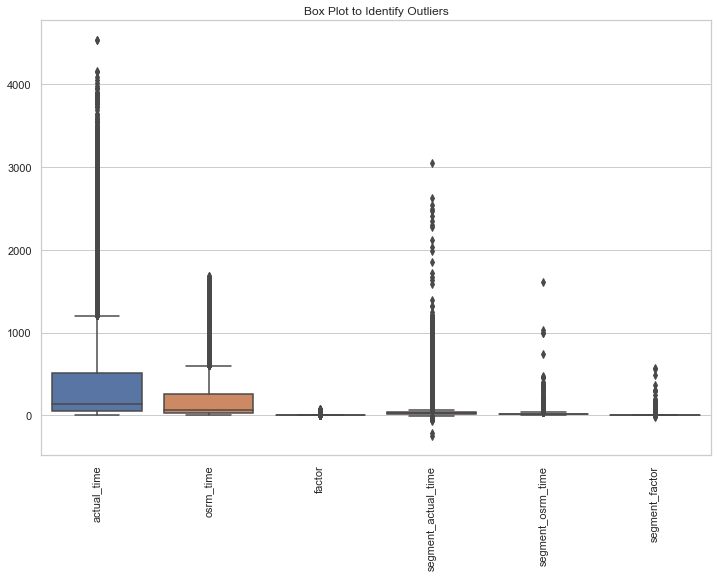

```python
# Box plot to identify outliers in numerical columns
plt.figure(figsize=(12, 8))
sns.boxplot(data=data[['actual_time', 'osrm_time', 'factor', 'segment_actual_time', 'segment_osrm_time', 'segment_factor']])
plt.title('Box Plot to Identify Outliers')
plt.xticks(rotation=90)
plt.show()

# Calculating Q1 and Q3
Q1 = data['actual_time'].quantile(0.25)
Q3 = data['actual_time'].quantile(0.75)
IQR = Q3 - Q1

#Remove outliers using IQR method for 'actual_time'
data = data[(data['actual_time'] >= Q1 - 1.5 * IQR) & (data['actual_time'] <= Q3 + 1.5 * IQR)]
```

###### This box plot illustrates the distribution of travel time estimates to identify outliers.

##### Outlier detection using the IQR method and Box Plot Visualization

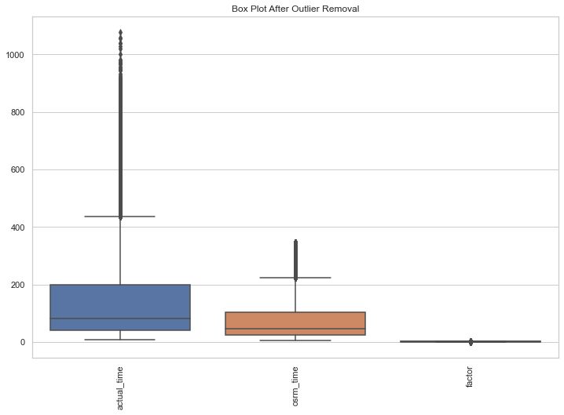

```python
import matplotlib.pyplot as plt
import seaborn as sns

# Outlier detection using IQR method
def remove_outliers(df, columns):
    for col in columns:
        Q1 = df[col].quantile(0.25)
        Q3 = df[col].quantile(0.75)
        IQR = Q3 - Q1
        lower_bound = Q1 - 1.5 * IQR
        upper_bound = Q3 + 1.5 * IQR
        df = df[(df[col] >= lower_bound) & (df[col] <= upper_bound)]
    return df

# Applying outlier removal function
columns_to_check = ['actual_time', 'osrm_time', 'factor']
data_cleaned = remove_outliers(data, columns_to_check)

# Visualizing box plots after outlier removal
plt.figure(figsize=(12, 8))
sns.boxplot(data=data_cleaned[columns_to_check])
plt.title('Box Plot After Outlier Removal')
plt.xticks(rotation=90)
plt.show()
```

###### This box plot illustrates the distribution of travel time estimates after removing outliers using the IQR method.

##### Histograms for Distribution Visualization

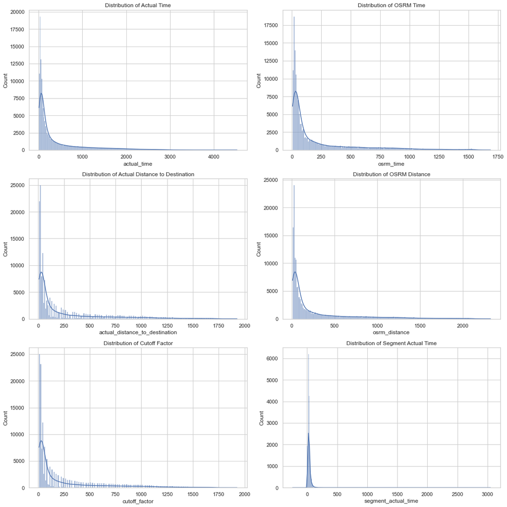

```python
import pandas as pd
import seaborn as sns
import matplotlib.pyplot as plt
data = pd.read_csv('C:\\Users\\HP\\OneDrive\\Desktop\\delhivery_data.csv')

# Setting style for seaborn
sns.set(style="whitegrid")

# Creating the figure and subplots
fig, axes = plt.subplots(3, 2, figsize=(15, 15))

# Plot histograms with KDE(kernel density estimate)
sns.histplot(data['actual_time'], kde=True, ax=axes[0, 0])
axes[0, 0].set_title('Distribution of Actual Time')

sns.histplot(data['osrm_time'], kde=True, ax=axes[0, 1])
axes[0, 1].set_title('Distribution of OSRM Time')

sns.histplot(data['actual_distance_to_destination'], kde=True, ax=axes[1, 0])
axes[1, 0].set_title('Distribution of Actual Distance to Destination')

sns.histplot(data['osrm_distance'], kde=True, ax=axes[1, 1])
axes[1, 1].set_title('Distribution of OSRM Distance')

sns.histplot(data['cutoff_factor'], kde=True, ax=axes[2, 0])
axes[2, 0].set_title('Distribution of Cutoff Factor')

sns.histplot(data['segment_actual_time'], kde=True, ax=axes[2, 1])
axes[2, 1].set_title('Distribution of Segment Actual Time')

# Adjust layout
plt.tight_layout()
plt.show()
```

###### Each histogram with KDE plot visualizes the distribution of key variables from the dataset, offering insights into their spread and shape.

###### Countplot for categorical Variables

[figure not shown]

[figure not shown]

```python
#count of source names
plt.figure(figsize=(10, 6))
sns.countplot(y='source_name', data=data, order=data['source_name'].value_counts().index)
plt.title('Count of Source Names')
plt.show()

#count of destination names
plt.figure(figsize=(10, 6))
sns.countplot(y='destination_name', data=data, order=data['destination_name'].value_counts().index)
plt.title('Count of Destination Names')
plt.show()
```

###### Each count plot visualizes the distribution of source and destination names, highlighting their frequency in the dataset.

#### analysis and visualization of trips by day of the week

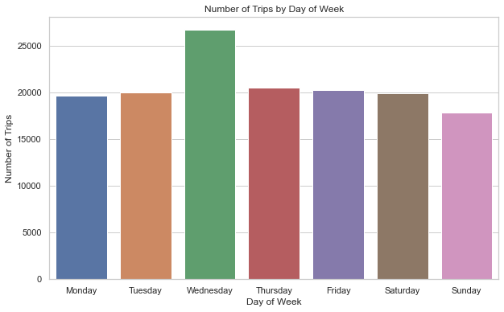

```python
# Extract day of week from trip_creation_time
data['day_of_week'] = data['trip_creation_time'].dt.day_name()

# Analyze trips by day of week
plt.figure(figsize=(10, 6))
sns.countplot(x='day_of_week', data=data, order=['Monday', 'Tuesday', 'Wednesday', 'Thursday', 'Friday', 'Saturday', 'Sunday'])
plt.title('Number of Trips by Day of Week')
plt.xlabel('Day of Week')
plt.ylabel('Number of Trips')
plt.show()
```

###### The count plot illustrates the distribution of trips across days of the week, providing insights into daily variations in trip frequency.

#### Pie chart to plot the distribution of source names

[figure not shown]

```python
import pandas as pd
import matplotlib.pyplot as plt
import seaborn as sns

# Load the dataset
data = pd.read_csv(r'C:\Users\HP\OneDrive\Desktop\delhivery_data.csv')

# Create a pie chart for the distribution of 'source_name'
plt.figure(figsize=(8, 6))
data['source_name'].value_counts().plot(kind='pie', autopct='%1.1f%%', colors=sns.color_palette('pastel'))
plt.title('Distribution of Source Names')
plt.ylabel('')
plt.show()
```

###### Pie chart showing the distribution of source names in the dataset.

###### Time Series Analysis

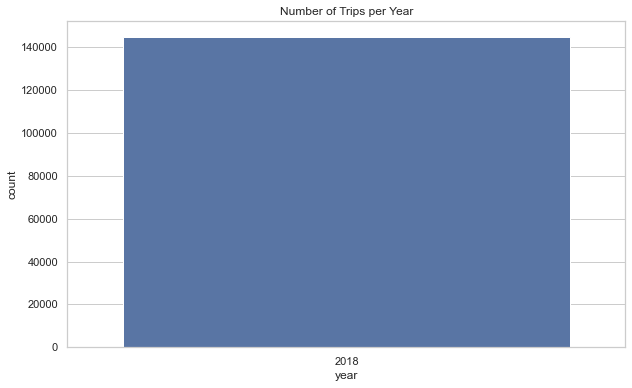

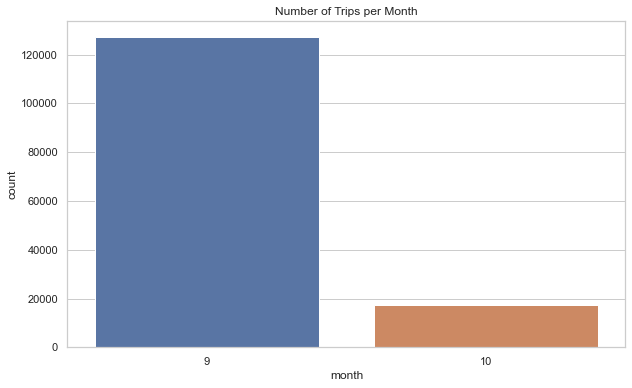

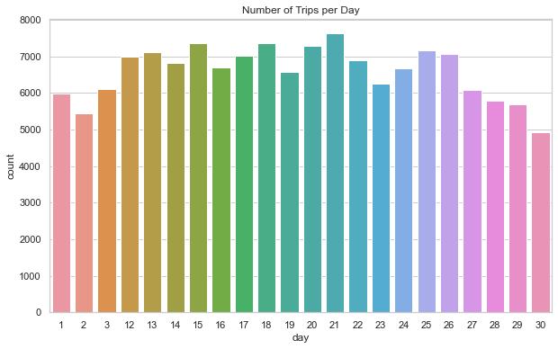

```python
# Time series analysis
data['trip_creation_time'] = pd.to_datetime(data['trip_creation_time'])

# Extract year from trip_creation_time
data['year'] = data['trip_creation_time'].dt.year

#Extract month from trip_creation_time
data['month'] = data['trip_creation_time'].dt.month

#Extract day from trip_creation_time
data['day'] = data['trip_creation_time'].dt.day

#trips per year
plt.figure(figsize=(10, 6))
sns.countplot(x='year', data=data)
plt.title('Number of Trips per Year')
plt.show()

#trips per month
plt.figure(figsize=(10, 6))
sns.countplot(x='month', data=data)
plt.title('Number of Trips per Month')
plt.show()

#trips per day
plt.figure(figsize=(10, 6))
sns.countplot(x='day', data=data)
plt.title('Number of Trips per Day')
plt.show()
```

###### Graphs depict the distribution of trips per year, month, and day, showcasing patterns in trip creation over time.

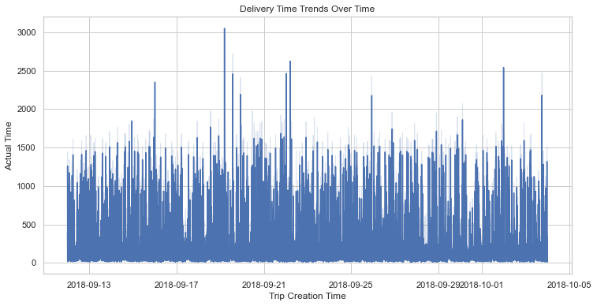

```python
# Time series analysis of delivery times over time
data['trip_creation_time'] = pd.to_datetime(data['trip_creation_time'])

plt.figure(figsize=(12, 6))
sns.lineplot(x='trip_creation_time', y='actual_time', data=data)
plt.title('Delivery Time Trends Over Time')
plt.xlabel('Trip Creation Time')
plt.ylabel('Actual Time')
plt.show()
```

###### This graph visualizes the trend of actual delivery times over the period of trip creation, providing insights into temporal delivery performance

## BIVARIATE ANALYSIS

##### SCATTERPLOT BETWEEN ACTUALTIME AND OSRM TIME

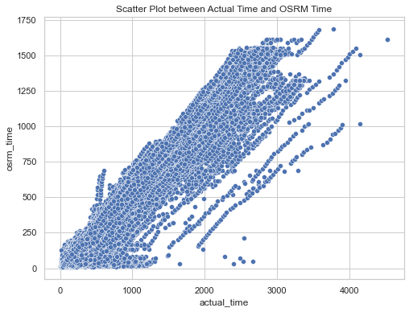

```python
plt.figure(figsize=(8, 6))
sns.scatterplot(x='actual_time', y='osrm_time', data=data)
plt.title('Scatter Plot between Actual Time and OSRM Time')
plt.show()
```

###### This scatter plot illustrates the relationship between actual delivery times and OSRM estimated times, highlighting potential discrepancies or agreements between predicted and observed delivery durations.

##### Box Plots of Actual Time by Source and Destination

[figure not shown]

[figure not shown]

```python
#Box plot of actual time for each source name
plt.figure(figsize=(12, 8))
sns.boxplot(x='source_name', y='actual_time', data=data)
plt.title('Box Plot of Actual Time by Source Name')
plt.xticks(rotation=90)
plt.show()

#Box plot of actual time for each destination name
plt.figure(figsize=(12, 8))
sns.boxplot(x='destination_name', y='actual_time', data=data)
plt.title('Box Plot of Actual Time by Destination Name')
plt.xticks(rotation=90)
plt.show()
```

###### Box plots show the distribution of actual delivery times across different source and destination names, revealing variability in time durations.

##### Correlation Matrix and Heatmap

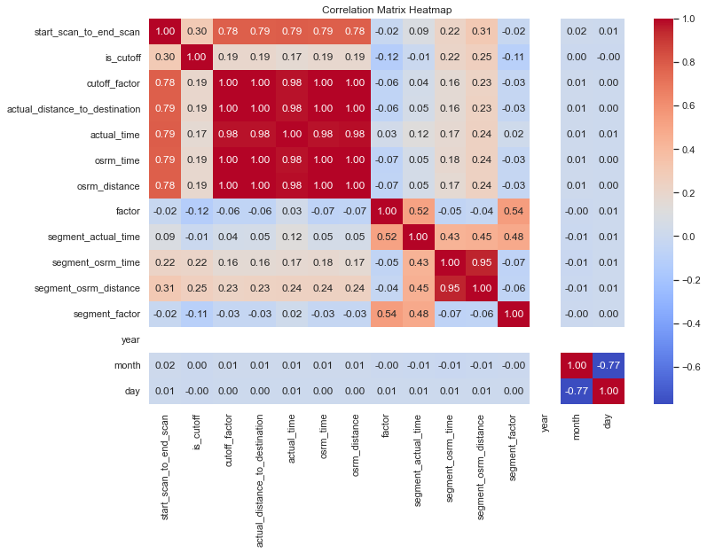

```python
# Correlation matrix
corr_matrix = data.corr()

# Heatmap of the correlation matrix
plt.figure(figsize=(12, 8))
sns.heatmap(corr_matrix, annot=True, cmap='coolwarm', fmt='.2f')
plt.title('Correlation Matrix Heatmap')
plt.show()
```

###### This heatmap displays the correlation matrix of variables, illustrating pairwise relationships between factors influencing delivery times.

##### Violin Plot of Actual Time by Source Name

[figure not shown]

```python
# Violin plots for comparing distributions
plt.figure(figsize=(12, 8))
sns.violinplot(x='source_name', y='actual_time', data=data)
plt.title('Violin Plot of Actual Time by Source Name')
plt.xlabel('Source Name')
plt.ylabel('Actual Time')
plt.xticks(rotation=90)
plt.show()
```

###### This violin plot compares the distribution of actual delivery times across different source locations, highlighting variations in delivery durations.

##### Performing a T-test between two groups

```python
from scipy.stats import ttest_ind

# Perform T-test between two groups (like different source locations)
group1 = data[data['source_name'] == 'Source1']['actual_time']
group2 = data[data['source_name'] == 'Source2']['actual_time']

t_stat, p_value = ttest_ind(group1, group2)
print('T-statistic:', t_stat)
print('p-value:', p_value)
```

```
T-statistic: nan
p-value: nan
```

###### T-statistic: Measures the size of the difference relative to the variation in your sample data.

###### P-value: Indicates the probability that the observed difference could have occurred just by random chance.

## MULTIVARIATE ANALYSIS

#### Pair Plot for Numerical Variables

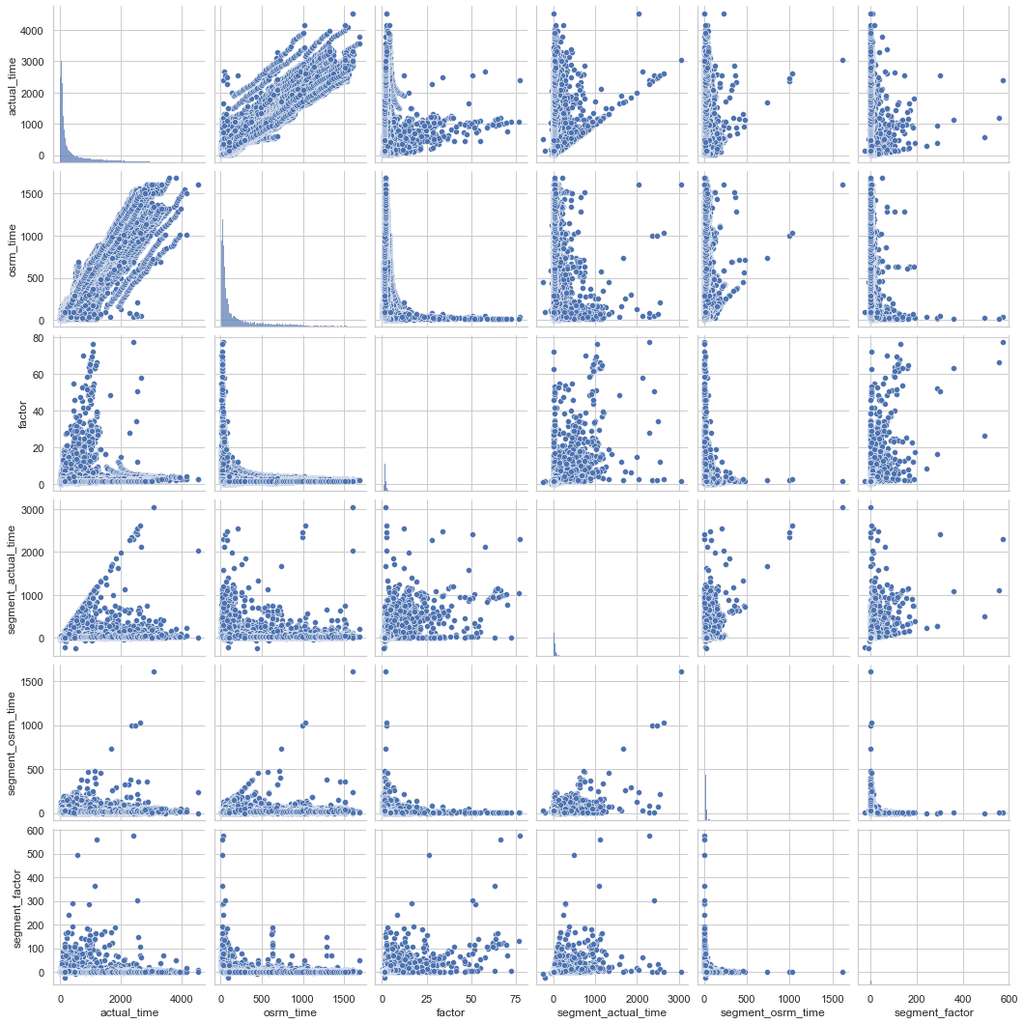

```python
sns.pairplot(data[['actual_time', 'osrm_time', 'factor', 'segment_actual_time', 'segment_osrm_time', 'segment_factor']])
plt.show()
```

###### This pair plot visualizes pairwise relationships among actual delivery time, OSRM time, factors, segment actual time, segment OSRM time, and segment factors, providing insights into their correlations and distributions.

#### K-means Clustering

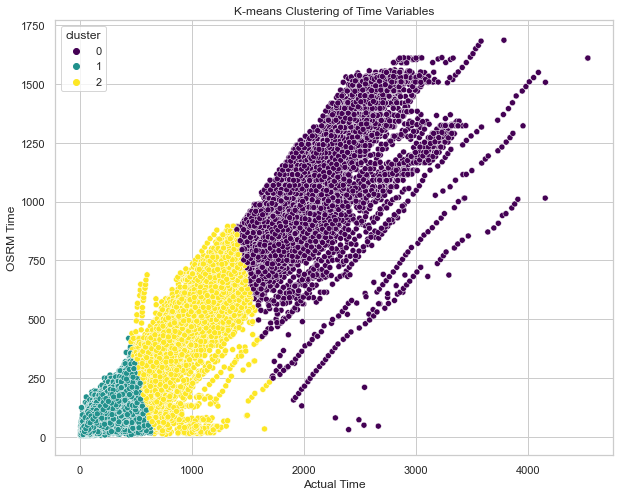

```python
#clustering analysis (kmeans)
from sklearn.cluster import KMeans
X_clustering = data[['actual_time', 'osrm_time']]

# Applying K-means clustering : unsupervised(raw data) learning algorithm that is used to solve the clustering problems in machine learning or data science.
kmeans = KMeans(n_clusters=3, random_state=42)
data['cluster'] = kmeans.fit_predict(X_clustering)

# Visualizing clustering results
plt.figure(figsize=(10, 8))
sns.scatterplot(x='actual_time', y='osrm_time', hue='cluster', data=data, palette='viridis')
plt.title('K-means Clustering of Time Variables')
plt.xlabel('Actual Time')
plt.ylabel('OSRM Time')
plt.show()
```

###### This scatter plot applies K-means clustering to actual time and OSRM time, categorizing data points into clusters based on similar delivery time patterns.

##### geospatial distribution of trips

```python
import pandas as pd  #for data manipulation and analysis
import seaborn as sns #for datavisualization
import matplotlib.pyplot as plt #for plotting
file_path = r'C:\Users\HP\OneDrive\Desktop\delhivery_data.csv'
data = pd.read_csv(file_path)

# Check if latitude and longitude columns exist
if 'latitude' in data.columns and 'longitude' in data.columns:

    # Convert latitude and longitude to numeric, handle errors
    data['latitude'] = pd.to_numeric(data['latitude'], errors='coerce')
    data['longitude'] = pd.to_numeric(data['longitude'], errors='coerce')

    # Drop rows with missing latitude or longitude values
    data = data.dropna(subset=['latitude', 'longitude'])

    # Plot geospatial distribution of trips
    plt.figure(figsize=(10, 8))
    sns.scatterplot(x='longitude', y='latitude', data=data)
    plt.title('Geospatial Distribution of Trips')
    plt.xlabel('Longitude')
    plt.ylabel('Latitude')
    plt.show()
else:
    print("Latitude and/or longitude columns not found in the dataset.")
```

```
Latitude and/or longitude columns not found in the dataset.
```

### KEY INSIGHTS

##### Time Series Analysis:Understanding the number of trips per year, month, and day can help in identifying trends and peak periods, aiding in better planning and management.

##### Scatter Plot and Correlation: The scatter plot and correlation matrix provide insights into the relationship between actual and OSRM times, indicating potential areas for improvement in time estimation.

##### Box and Violin Plots:The box and violin plots reveal the distribution and variability of actual times across different sources and destinations, highlighting potential areas where performance can be improved.

##### Clustering:K-means clustering helps segment the trips into different clusters based on time metrics, which can be useful for identifying patterns and making data-driven decisions.

## CONCLUSION

##### The analysis revealed significant insights into delivery operations. By optimizing routes using actual versus estimated times, allocating resources based on high-demand areas, and anticipating peak periods through trend analysis, businesses can streamline logistics. Improvements in time estimates and effective outlier management enhance operational reliability. Furthermore, investigating delivery clusters provides targeted strategies for improving efficiency. Implementing these data-driven approaches not only enhances operational efficiency and customer satisfaction but also strengthens competitiveness in the logistics sector.

### Recommendations

##### To optimize routes, leverage the correlation between actual and OSRM times to refine route planning, potentially reducing delivery times. Efficient resource allocation can be achieved by focusing on the most frequently used sources and destinations, ensuring optimal utilization. Trend analysis from time series data helps prepare for peak periods, allowing for adequate staffing and resources during high-demand times. Improving the accuracy of OSRM time estimates involves analyzing discrepancies and adjusting estimation models accordingly. Regularly identifying and managing outliers is crucial to maintaining the quality and reliability of data for analysis and reporting. Further, investigating the characteristics of different clusters identified through K-means clustering can help understand and address factors contributing to varied delivery times, enhancing overall efficiency.